# DA 5020 Assignment 11

Jiaming Xu

## 1. Loading data

```r
library(tidyverse)
df <- read_csv("diabetes.csv")
summary(df)
```

```
##   Pregnancies        Glucose      BloodPressure    SkinThickness
##  Min.   : 0.000   Min.   :  0.0   Min.   :  0.00   Min.   : 0.00
##  1st Qu.: 1.000   1st Qu.: 99.0   1st Qu.: 62.00   1st Qu.: 0.00
##  Median : 3.000   Median :117.0   Median : 72.00   Median :23.00
##  Mean   : 3.845   Mean   :120.9   Mean   : 69.11   Mean   :20.54
##  3rd Qu.: 6.000   3rd Qu.:140.2   3rd Qu.: 80.00   3rd Qu.:32.00
##  Max.   :17.000   Max.   :199.0   Max.   :122.00   Max.   :99.00
##     Insulin           BMI        DiabetesPedigreeFunction      Age
##  Min.   :  0.0   Min.   : 0.00   Min.   :0.0780           Min.   :21.00
##  1st Qu.:  0.0   1st Qu.:27.30   1st Qu.:0.2437           1st Qu.:24.00
##  Median : 30.5   Median :32.00   Median :0.3725           Median :29.00
##  Mean   : 79.8   Mean   :31.99   Mean   :0.4719           Mean   :33.24
##  3rd Qu.:127.2   3rd Qu.:36.60   3rd Qu.:0.6262           3rd Qu.:41.00
##  Max.   :846.0   Max.   :67.10   Max.   :2.4200           Max.   :81.00
##     Outcome
##  Min.   :0.000
##  1st Qu.:0.000
##  Median :0.000
##  Mean   :0.349
##  3rd Qu.:1.000
##  Max.   :1.000
```

```r
glimpse(df)
```

```
## Rows: 768
## Columns: 9
## $ Pregnancies              <dbl> 6, 1, 8, 1, 0, 5, 3, 10, 2, 8, 4, 10, 10, 1, …
## $ Glucose                  <dbl> 148, 85, 183, 89, 137, 116, 78, 115, 197, 125…
## $ BloodPressure            <dbl> 72, 66, 64, 66, 40, 74, 50, 0, 70, 96, 92, 74…
## $ SkinThickness            <dbl> 35, 29, 0, 23, 35, 0, 32, 0, 45, 0, 0, 0, 0, …
## $ Insulin                  <dbl> 0, 0, 0, 94, 168, 0, 88, 0, 543, 0, 0, 0, 0, …
## $ BMI                      <dbl> 33.6, 26.6, 23.3, 28.1, 43.1, 25.6, 31.0, 35.…
## $ DiabetesPedigreeFunction <dbl> 0.627, 0.351, 0.672, 0.167, 2.288, 0.201, 0.2…
## $ Age                      <dbl> 50, 31, 32, 21, 33, 30, 26, 29, 53, 54, 30, 3…
## $ Outcome                  <dbl> 1, 0, 1, 0, 1, 0, 1, 0, 1, 1, 0, 1, 0, 1, 1, …
```

```r
sapply(df, function(x){sum(is.na(x))})
```

```
##              Pregnancies                  Glucose            BloodPressure
##                        0                        0                        0
##            SkinThickness                  Insulin                      BMI
##                        0                        0                        0
## DiabetesPedigreeFunction                      Age                  Outcome
##                        0                        0                        0
```

There are 9 columns containing numeric values. No missing values. Therefore, we can perform min-max normalization directly on the whole dataset.

## 2. Normalization.

1. Create a min-max normalization function.
2. Using sapply to apply norma function to whole df.

```r
norma <- function(x){
  (x-min(x))/(max(x)-min(x))
}

df.norm <- sapply(df, norma) %>% as.data.frame()
```

## 3. Split data into training/testing

1. using sample function to pick indeces for 0.8*nrow(df) rows randomly.
2. split data into two data frames.

```r
set.seed((7))
train_sample_idx <- sample(1:nrow(df.norm), 0.8*nrow(df.norm), replace = FALSE)
train_sample <- df.norm[train_sample_idx, -9]
test_sample <- df.norm[-train_sample_idx, -9]
train_sample_label <- df.norm[train_sample_idx, 9]
test_sample_label <- df.norm[-train_sample_idx, 9]
```

## 4. Create in house KNN function.

my_kNN:

1. create an empty modes_output vector for output.
2. loop through each row in the test data set.
3. inside loop: use sweep function to substract train data set by a row in the test data sett save to data set a. Then square the values in a, sort it, then take the indeces of the first k rows, to top_index. then use getMode function to find the most common value in of these indeces in train_labels. Append result into modes_output.

```r
getMode <- function(x) {
    ## Took and modified from https://www.delftstack.com/howto/r/mode-in-r/.
    u <- unique(x)
    return (u[which.max(tabulate(match(x, u)))])
}

# Inputs: train data, test data, label of train data, and k.
knn_predict <- function( train, test, cl, k){
    modes_output <- vector()
    for (i in 1:nrow(test)) {
        a <- sweep( as.matrix(train), 2, as.matrix(test[i, ])) %>% as_tibble()
        top_index <- sort(rowSums(a^2), index.return=T)$ix[1:k]
        mode <- cl[top_index] %>% getMode()
        modes_output <- append(modes_output, mode)
    }
    return (modes_output)
}
```

## 5. Analyze KNN result.

How KNN works:

1. Looping each row in test sample, and subatract the train sample by each row in test sample.
2. Calculate the sum of squared values in each row, then sort it ascending. The smaller the value, the moer near the points. Pick the indeces of top k smallest values.
3. Finding the mode of the target of these k observations.
4. Append to the output vector.

```r
library(gmodels)

knn_4 <- knn_predict(train_sample, test_sample, train_sample_label, 4)
CrossTable(knn_4, test_sample_label)
```

```
##
##
##    Cell Contents
## |-------------------------|
## |                       N |
## | Chi-square contribution |
## |           N / Row Total |
## |           N / Col Total |
## |         N / Table Total |
## |-------------------------|
##
##
## Total Observations in Table:  154
##
##
##              | test_sample_label
##        knn_4 |         0 |         1 | Row Total |
## -------------|-----------|-----------|-----------|
##            0 |        73 |        23 |        96 |
##              |     3.895 |     5.938 |           |
##              |     0.760 |     0.240 |     0.623 |
##              |     0.785 |     0.377 |           |
##              |     0.474 |     0.149 |           |
## -------------|-----------|-----------|-----------|
##            1 |        20 |        38 |        58 |
##              |     6.446 |     9.828 |           |
##              |     0.345 |     0.655 |     0.377 |
##              |     0.215 |     0.623 |           |
##              |     0.130 |     0.247 |           |
## -------------|-----------|-----------|-----------|
## Column Total |        93 |        61 |       154 |
##              |     0.604 |     0.396 |           |
## -------------|-----------|-----------|-----------|
##
##
```

```r
knn_6 <- knn_predict(train_sample, test_sample, train_sample_label, 6)
CrossTable(knn_6, test_sample_label)
```

```
##
##
##    Cell Contents
## |-------------------------|
## |                       N |
## | Chi-square contribution |
## |           N / Row Total |
## |           N / Col Total |
## |         N / Table Total |
## |-------------------------|
##
##
## Total Observations in Table:  154
##
##
##              | test_sample_label
##        knn_6 |         0 |         1 | Row Total |
## -------------|-----------|-----------|-----------|
##            0 |        73 |        25 |        98 |
##              |     3.226 |     4.919 |           |
##              |     0.745 |     0.255 |     0.636 |
##              |     0.785 |     0.410 |           |
##              |     0.474 |     0.162 |           |
## -------------|-----------|-----------|-----------|
##            1 |        20 |        36 |        56 |
##              |     5.646 |     8.608 |           |
##              |     0.357 |     0.643 |     0.364 |
##              |     0.215 |     0.590 |           |
##              |     0.130 |     0.234 |           |
## -------------|-----------|-----------|-----------|
## Column Total |        93 |        61 |       154 |
##              |     0.604 |     0.396 |           |
## -------------|-----------|-----------|-----------|
##
##
```

```r
knn_8 <- knn_predict(train_sample, test_sample, train_sample_label, 8)
CrossTable(knn_8, test_sample_label)
```

```
##
##
##    Cell Contents
## |-------------------------|
## |                       N |
## | Chi-square contribution |
## |           N / Row Total |
## |           N / Col Total |
## |         N / Table Total |
## |-------------------------|
##
##
## Total Observations in Table:  154
##
##
##              | test_sample_label
##        knn_8 |         0 |         1 | Row Total |
## -------------|-----------|-----------|-----------|
##            0 |        78 |        26 |       104 |
##              |     3.676 |     5.605 |           |
##              |     0.750 |     0.250 |     0.675 |
##              |     0.839 |     0.426 |           |
##              |     0.506 |     0.169 |           |
## -------------|-----------|-----------|-----------|
##            1 |        15 |        35 |        50 |
##              |     7.646 |    11.658 |           |
##              |     0.300 |     0.700 |     0.325 |
##              |     0.161 |     0.574 |           |
##              |     0.097 |     0.227 |           |
## -------------|-----------|-----------|-----------|
## Column Total |        93 |        61 |       154 |
##              |     0.604 |     0.396 |           |
## -------------|-----------|-----------|-----------|
##
##
```

From results above we can see that knn performs better with a relatively larger k among 4,6,8.

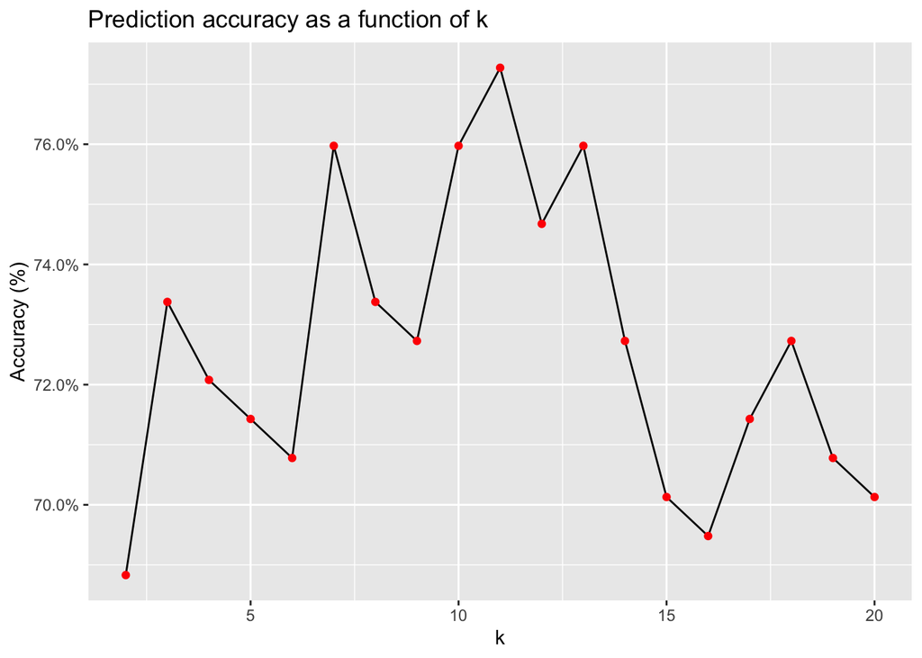

```r
set.seed(7)
acc_rate <- vector()
for (k in 2:20) {
  df_pred <-  knn_predict(train_sample,
                test_sample,
                train_sample_label, k= k)
  acc_rate <- append(acc_rate, sum(df_pred == test_sample_label)/ length(test_sample_label))
}

ggplot( ) +
  geom_line( mapping = aes(x = seq(2, 20), y = acc_rate)) +
  geom_point( mapping = aes( x = seq(2, 20), y = acc_rate), color = 'red') +
  labs( title = "Prediction accuracy as a function of k", x = 'k', y = 'Accuracy (%)') +
  scale_y_continuous(labels = scales::percent)
```

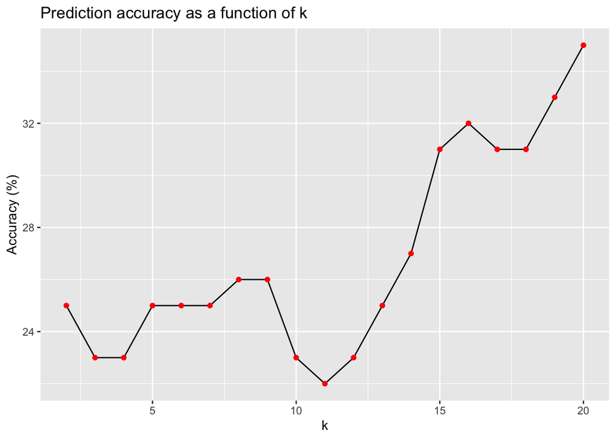

```r
false_negative <- function(pred_rst, real_rst){
  sum((pred_rst == 0) & (real_rst == 1))
}

set.seed(7)
fn_rate <- vector()
for (k in 2:20) {
  df_pred <-  knn_predict(train_sample,
                test_sample,
                train_sample_label, k= k)
  fn_rate <- append(fn_rate, false_negative(df_pred, test_sample_label))
}

ggplot( ) +
  geom_line( mapping = aes(x = seq(2,20), y = fn_rate)) +
  geom_point( mapping = aes( x = seq(2, 20), y = fn_rate), color = 'red') +
  labs( title = "Prediction accuracy as a function of k", x = 'k', y = 'Accuracy (%)')
```

If we want to minimize our false negative, we may want to use k = 3,4,10,11, or 12.